# Real Estate Analysis: Focus on Oldtown

Mia Murphy

2023-10-23

# Introduction

This document provides a comprehensive analysis of real estate properties located in the “Oldtown” neighborhood. We aim to uncover trends, evaluate property characteristics, and identify unique aspects of historical properties in this area.

### Data Loading

First, we will load the real estate data set and filter out the properties located in “Oldtown.”

```r
data <- read_csv("train2.csv")
oldtown_data <- data %>% filter(Neighborhood == "OldTown")
```

### Sale Price Distribution

Let’s start by examining the distribution of sale prices in “Oldtown.”

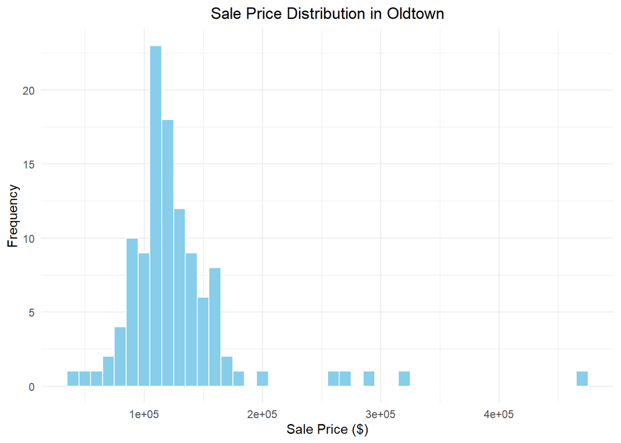

```r
ggplot(oldtown_data, aes(x = SalePrice)) +
  geom_histogram(binwidth = 10000, fill = "skyblue", color = "white") +
  labs(title = "Sale Price Distribution in Oldtown", x = "Sale Price ($)", y = "Frequency") +
  theme_minimal() +
  theme(plot.title = element_text(hjust = 0.5))
```

### Sale Price by Property Type

Next, we will analyze how the sale prices vary by property type.

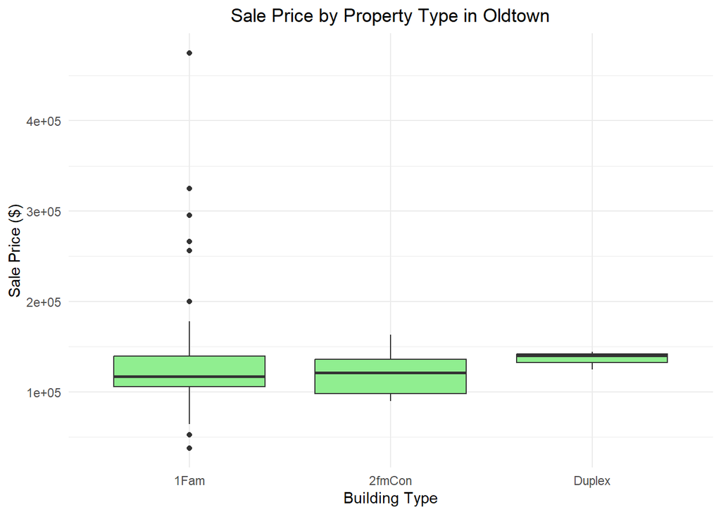

```r
ggplot(oldtown_data, aes(x = BldgType, y = SalePrice)) +
  geom_boxplot(fill = "lightgreen") +
  labs(title = "Sale Price by Property Type in Oldtown", x = "Building Type", y = "Sale Price ($)") +
  theme_minimal() +
  theme(plot.title = element_text(hjust = 0.5))
```

### Historical Properties Analysis

We define historical properties as those built before 1930. Let’s compare historical and non-historical properties.

```r
oldtown_data <- oldtown_data %>% mutate(Historical = if_else(YearBuilt < 1930, "Historical", "Non-Historical"))
summary_stats <- oldtown_data %>%
  group_by(Historical) %>%
  summarise(
    Avg_SalePrice = mean(SalePrice),
    Median_SalePrice = median(SalePrice),
    Avg_OverallQual = mean(as.numeric(OverallQual)),
    Median_OverallQual = median(as.numeric(OverallQual)),
    Avg_GrLivArea = mean(GrLivArea),
    Median_GrLivArea = median(GrLivArea)
  )

kable(summary_stats, caption = "Summary Statistics for Historical vs Non-Historical Properties")
```

Summary Statistics for Historical vs Non-Historical Properties

| Historical | Avg_SalePrice | Median_SalePrice | Avg_OverallQual | Median_OverallQual | Avg_GrLivArea | Median_GrLivArea |
| --- | --- | --- | --- | --- | --- | --- |
| Historical | 133687.2 | 122000 | 5.584416 | 5 | 1638.286 | 1539 |
| Non-Historical | 116542.9 | 116000 | 4.972222 | 5 | 1140.583 | 1087 |

# Visualizations

### Sale Price Distribution by Historical Status

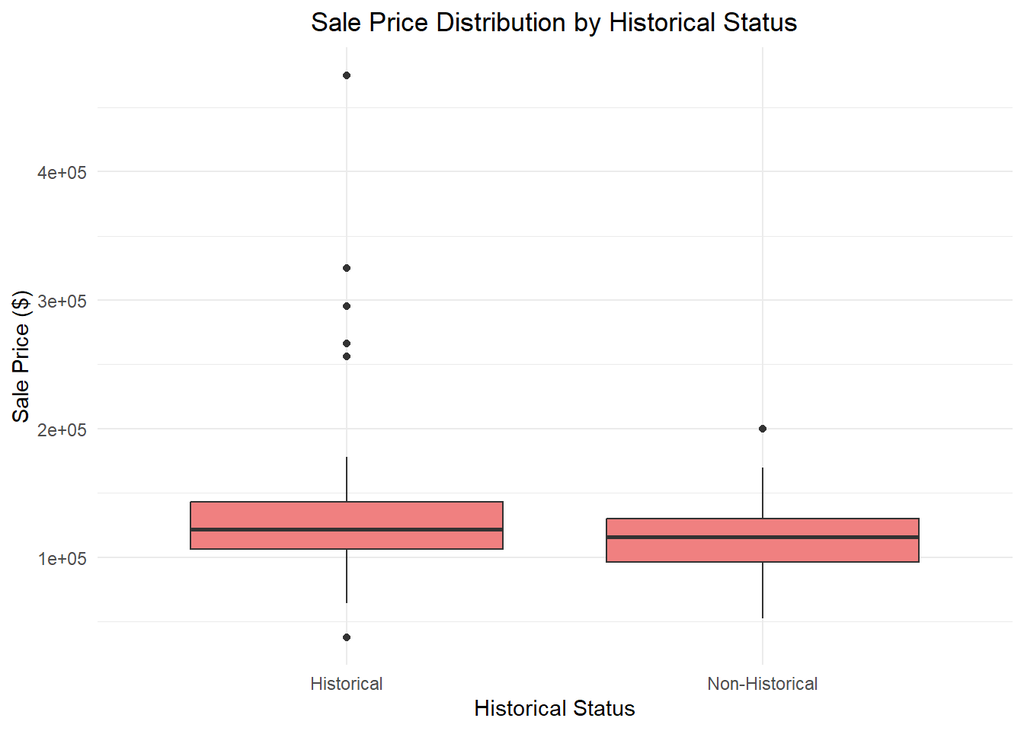

```r
ggplot(oldtown_data, aes(x = Historical, y = SalePrice)) +
  geom_boxplot(fill = "lightcoral") +
  labs(title = "Sale Price Distribution by Historical Status", x = "Historical Status", y = "Sale Price ($)") +
  theme_minimal() +
  theme(plot.title = element_text(hjust = 0.5))
```

### Overall Quality Distribution by Historical Status

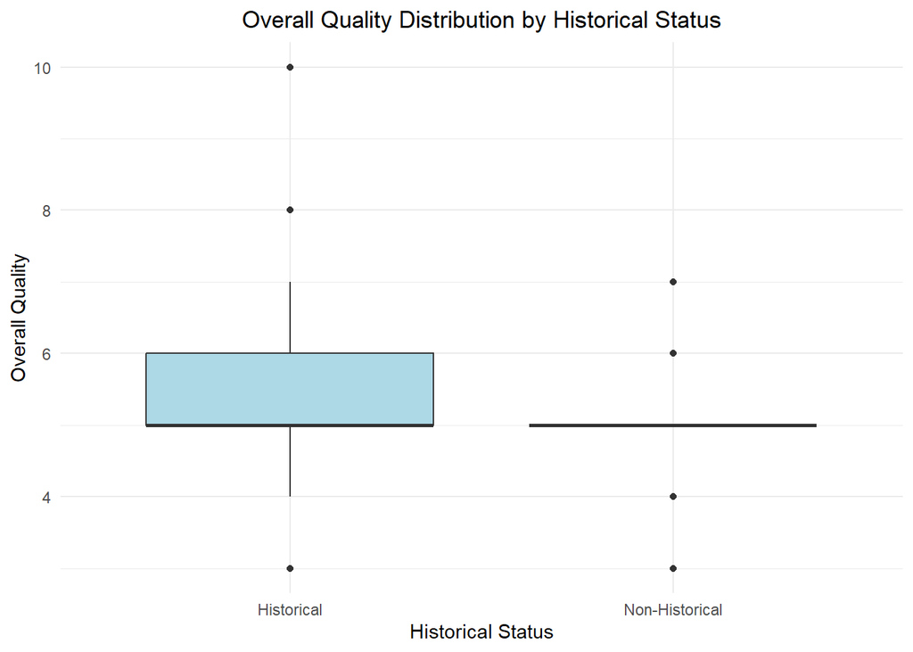

```r
ggplot(oldtown_data, aes(x = Historical, y = as.numeric(OverallQual))) +
  geom_boxplot(fill = "lightblue") +
  labs(title = "Overall Quality Distribution by Historical Status", x = "Historical Status", y = "Overall Quality") +
  theme_minimal() +
  theme(plot.title = element_text(hjust = 0.5))
```

### Sale Price vs Living Area by Historical Status

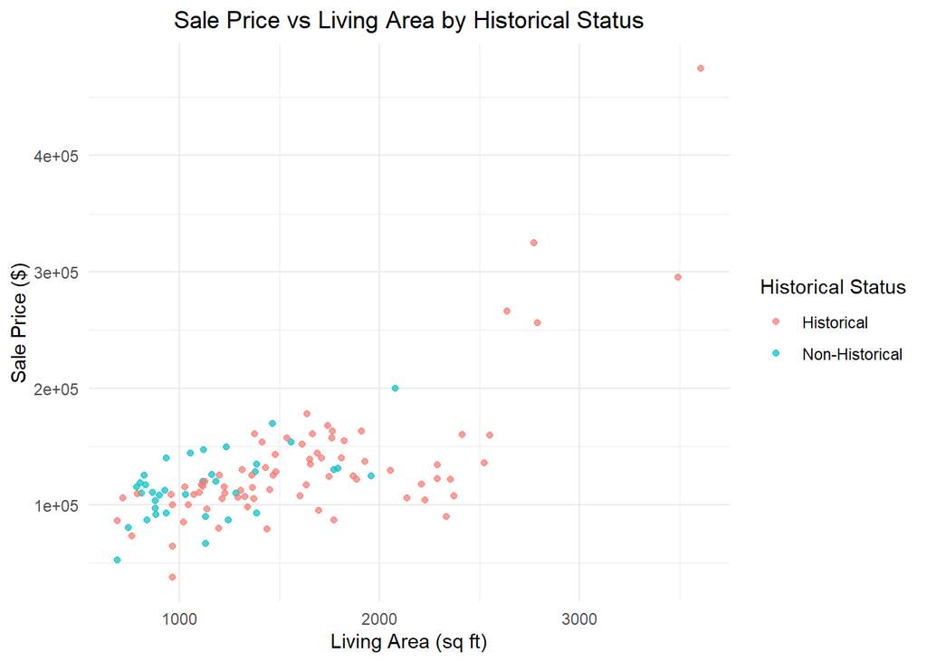

```r
ggplot(oldtown_data, aes(x = GrLivArea, y = SalePrice, color = Historical)) +
  geom_point(alpha = 0.7) +
  labs(title = "Sale Price vs Living Area by Historical Status", x = "Living Area (sq ft)", y = "Sale Price ($)", color = "Historical Status") +
  theme_minimal() +
  theme(plot.title = element_text(hjust = 0.5))
```

# Garage types over the years

1. Visualize Garage Types in OldTown

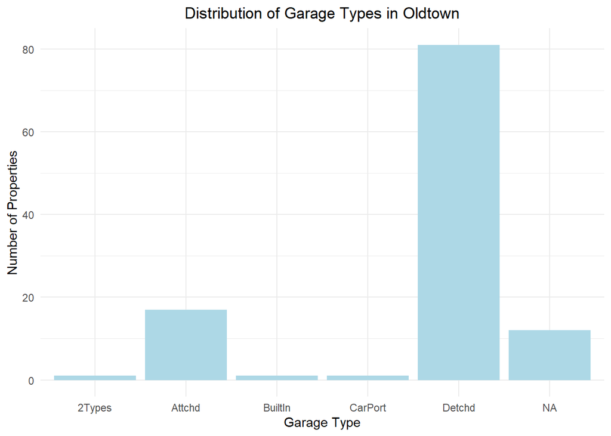

```r
ggplot(oldtown_data, aes(x = GarageType)) +
  geom_bar(fill = "lightblue") +
  labs(title = "Distribution of Garage Types in Oldtown", x = "Garage Type", y = "Number of Properties") +
  theme_minimal() +
  theme(plot.title = element_text(hjust = 0.5))
```

2. Examine Garage Types Over Time

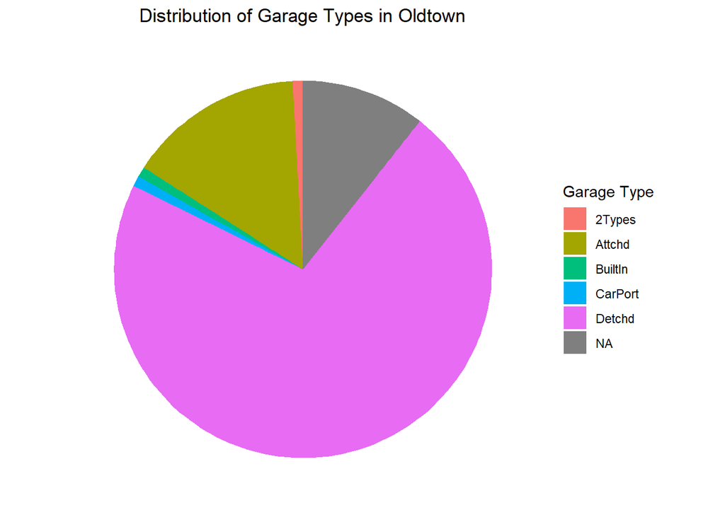

```r
# Preparing the data for the pie chart
garage_data <- oldtown_data %>%
  group_by(GarageType) %>%
  summarise(Count = n()) %>%
  mutate(Percentage = Count / sum(Count) * 100)

# Creating the pie chart
ggplot(garage_data, aes(x = "", y = Percentage, fill = GarageType)) +
  geom_bar(stat = "identity", width = 1) +
  coord_polar("y") +
  labs(title = "Distribution of Garage Types in Oldtown", x = NULL, y = NULL, fill = "Garage Type") +
  theme_minimal() +
  theme(axis.text = element_blank(), axis.title = element_blank(), panel.grid = element_blank(),
        plot.title = element_text(hjust = 0.5))
```

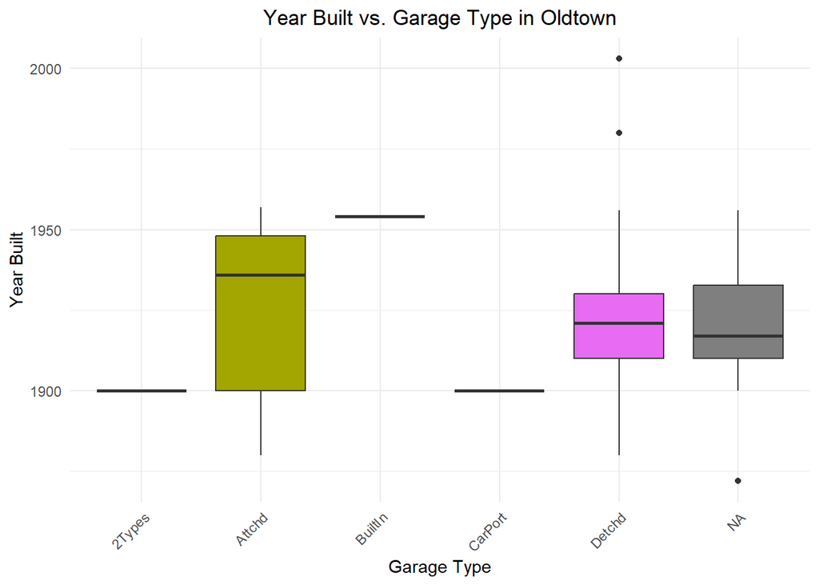

```r
# Creating the box plot
ggplot(oldtown_data, aes(x = GarageType, y = YearBuilt, fill = GarageType)) +
  geom_boxplot() +
  labs(title = "Year Built vs. Garage Type in Oldtown", x = "Garage Type", y = "Year Built") +
  theme_minimal() +
  theme(axis.text.x = element_text(angle = 45, hjust = 1),
        legend.title = element_blank(),
        plot.title = element_text(hjust = 0.5),
        legend.position = "none")
```

# Conclusion

The analysis provides a detailed insight into the real estate properties in “Oldtown,” highlighting the characteristics of historical properties. Historical properties in this neighborhood tend to have higher sale prices, larger living areas, and a diverse range of overall qualities. This comprehensive analysis serves as a valuable resource for understanding property trends in “Oldtown,” aiding in informed decision-making for potential buyers, sellers, and investors.